# SL with train on SAIS

@CorradoLanera

2019-02-15

## Setup

Prima di cominciare carichiamo i pacchetti necessari

```r
library(SuperLearner)
# devtools::install_github("UBESP-DCTV/select")    # NOTE: it's private!
library(select)

# devtools::install_github(CorradoLanera/depigner) # NOTE: it's open
library(depigner)
library(DT)
library(pander)
    panderOptions("table.split.table", Inf)

library(tidyverse)
library(Hmisc)
set.seed(1)
```

## Caricamento dati

Importiamo i dati che ci interessano, ovvero quelli per i trial SAIS (su cui addestreremo il nostromodello SL) e i dati PROLOGUE (su cui lo testeremo).

Ricordiamo che useremo solo le variabili comuni a entrambi i trial. Inoltre ricordimao anche che i dati mancanti di tali variabili per lo studio PROLOGUE sono stati imputati a partire dal dataset completo.

```r
data("sais_selected", "prologue_miced_selected")

# ?sais_select
datatable(sais_selected)
```

|  | id | allocation | age | gender | bmi | hypertension_adj | dyslipidemia_adj | adiponectin | sbp | dbp | hba1c | fpg | ldl | delta_hba1c_dbl | delta_hba1c_fct |
| --- | --- | --- | --- | --- | --- | --- | --- | --- | --- | --- | --- | --- | --- | --- | --- |
| 1 | 56 | sitagliptin | 72 | female | 19.8 | True | False | 7.2 | 165 | 72 | 7.9 | 6.9 | 103 | -0.300000000000001 | HbA1c &gt; -0.5 |
| 2 | 57 | sitagliptin | 55 | female | 30.8 | False | True | 1.3 | 115 | 73 | 7.9 | 11.4 | 81 | -0.300000000000001 | HbA1c &gt; -0.5 |
| 3 | 58 | sitagliptin | 66 | male | 25.2 | False | False | 3.4 | 116 | 70 | 6.8 | 8.8 | 118 | -0.5 | HbA1c &lt;= -0.5 |
| 4 | 59 | sitagliptin | 70 | male | 23.5 | False | True | 1.4 | 117 | 65 | 7.3 | 7.6 | 118 | -0.7 | HbA1c &lt;= -0.5 |
| 5 | 60 | sitagliptin | 44 | male | 32.7 | True | True | 2.3 | 124 | 81 | 7.4 | 7.7 | 122 | -0.7 | HbA1c &lt;= -0.5 |
| 6 | 61 | sitagliptin | 35 | male | 28.7 | False | True | 9.9 | 112 | 64 | 7 | 7.2 | 93 | 0.2 | HbA1c &gt; -0.5 |
| 7 | 62 | sitagliptin | 59 | male | 26.2 | True | True | 2.4 | 124 | 86 | 7.8 | 9.4 | 127 | -0.6 | HbA1c &lt;= -0.5 |
| 8 | 63 | sitagliptin | 72 | male | 24.8 | True | False | 1.2 | 137 | 77 | 7.5 | 7.9 | 31 | -1 | HbA1c &lt;= -0.5 |
| 9 | 64 | sitagliptin | 66 | female | 26 | True | False | 7.6 | 145 | 84 | 7.1 | 8.2 | 117 | -0.899999999999999 | HbA1c &lt;= -0.5 |
| 10 | 65 | sitagliptin | 59 | male | 22.3 | False | True | 3.2 | 101 | 63 | 8.1 | 7.9 | 141 | -1.4 | HbA1c &lt;= -0.5 |

[output cut: 33 more lines]

```r
# ?prologue_miced_selected
datatable(prologue_miced_selected)
```

|  | id | allocation | age | gender | bmi | hypertension_adj | dyslipidemia_adj | adiponectin | sbp | dbp | hba1c | fpg | ldl | delta_hba1c_dbl | delta_hba1c_fct |
| --- | --- | --- | --- | --- | --- | --- | --- | --- | --- | --- | --- | --- | --- | --- | --- |
| 1 | PRL-001a-02 | conventional | 48 | male | 38.28125 | True | False | 2.88 | 152 | 92 | 6.5 | 119 | 112.8 | -0.399999999999999 | HbA1c &gt; -0.5 |
| 2 | PRL-001a-03 | conventional | 75 | female | 21.4756712952757 | False | False | 10.2 | 110 | 76 | 6.6 | 100 | 105.8 | -0.3 | HbA1c &gt; -0.5 |
| 3 | PRL-001a-04 | conventional | 76 | male | 24.6831955922865 | False | False | 0.86 | 106 | 62 | 7.2 | 125 | 63.8 | -1 | HbA1c &lt;= -0.5 |
| 4 | PRL-001a-06 | sitagliptin | 51 | male | 25.9697567389875 | True | True | 0.34 | 126 | 84 | 7.4 | 251 | 77 | 0.3 | HbA1c &gt; -0.5 |
| 5 | PRL-001a-07 | sitagliptin | 72 | male | 21.4885442385389 | False | False | 5.01 | 128 | 60 | 7.3 | 131 | 79.4 | -0.2 | HbA1c &gt; -0.5 |
| 6 | PRL-001a-08 | sitagliptin | 57 | male | 26.2053570896807 | True | True | 2.15 | 148 | 90 | 6.9 | 162 | 95 | -0.6 | HbA1c &lt;= -0.5 |
| 7 | PRL-002a-01 | conventional | 60 | male | 27.978887898049 | False | False | 1.56 | 112 | 54 | 7.4 | 160 | 77.4 | 0.0999999999999996 | HbA1c &gt; -0.5 |
| 8 | PRL-002a-03 | sitagliptin | 65 | male | 25.0743900019837 | True | True | 2.18 | 135 | 88 | 6.2 | 113 | 56.5 | -0.2 | HbA1c &gt; -0.5 |
| 9 | PRL-002a-05 | sitagliptin | 65 | female | 20.787653904537 | True | False | 4.68 | 146 | 70 | 6.3 | 83 | 77.7 | 0.0999999999999996 | HbA1c &gt; -0.5 |
| 10 | PRL-002a-06 | conventional | 79 | male | 21.1030176899063 | True | False | 9.11 | 157 | 92 | 6.9 | 130 | 94.1 | -0.2 | HbA1c &gt; -0.5 |

[output cut: 375 more lines]

## Learners

Ora carichiamo i parametri del SuperLearner, ovvero le combinazioni scelte di criteri di selezione delle variabili e di weak learners.

```r
data("sl_library")
# ?sl_library
sl_library
```

```
#> $SL.bartMachine
#> [1] "SL.bartMachine"      "All"                 "screen.randomForest"
#>
#> $SL.biglasso
#> [1] "SL.biglasso"         "All"                 "screen.randomForest"
#>
#> $SL.caret
#> [1] "SL.caret"            "All"                 "screen.randomForest"
#>
#> $SL.caret.rpart
#> [1] "SL.caret.rpart"      "All"                 "screen.randomForest"
#>
#> $SL.earth
#> [1] "SL.earth"            "All"                 "screen.randomForest"
#>
#> $SL.glmnet
#> [1] "SL.glmnet"           "All"                 "screen.randomForest"
#>
#> $SL.ipredbagg
#> [1] "SL.ipredbagg"        "All"                 "screen.randomForest"
#>
#> $SL.ksvm
#> [1] "SL.ksvm"             "All"                 "screen.randomForest"
#>
#> $SL.lm
#> [1] "SL.lm"               "All"                 "screen.randomForest"
#>
#> $SL.mean
#> [1] "SL.mean"             "All"                 "screen.randomForest"
#>
#> $SL.polymars
#> [1] "SL.polymars"         "All"                 "screen.randomForest"
#>
#> $SL.randomForest
#> [1] "SL.randomForest"     "All"                 "screen.randomForest"
#>
#> $SL.ranger
#> [1] "SL.ranger"           "All"                 "screen.randomForest"
#>
#> $SL.rpart
#> [1] "SL.rpart"            "All"                 "screen.randomForest"
#>
#> $SL.rpartPrune
#> [1] "SL.rpartPrune"       "All"                 "screen.randomForest"
#>
#> $SL.speedglm
#> [1] "SL.speedglm"         "All"                 "screen.randomForest"
#>
#> $SL.speedlm
#> [1] "SL.speedlm"          "All"                 "screen.randomForest"
#>
#> $SL.xgboost
#> [1] "SL.xgboost"          "All"                 "screen.randomForest"
```

## Addestramento

Procediamo quindi all’addestramento.

Innazitutto isoliamo per la base di dati di addestramento le informazioni da usare e le informazioni per la risposta.

```r
training_data <- dplyr::select(sais_selected,
        -id, -allocation, -delta_hba1c_dbl, -delta_hba1c_fct
    ) %>%
    as.data.frame() # required by SL

true_values <- as.integer( # required by SL
        sais_selected[["delta_hba1c_fct"]] == "HbA1c <= -0.5"
    )

datatable(training_data)
```

|  | age | gender | bmi | hypertension_adj | dyslipidemia_adj | adiponectin | sbp | dbp | hba1c | fpg | ldl |
| --- | --- | --- | --- | --- | --- | --- | --- | --- | --- | --- | --- |
| 1 | 72 | female | 19.8 | True | False | 7.2 | 165 | 72 | 7.9 | 6.9 | 103 |
| 2 | 55 | female | 30.8 | False | True | 1.3 | 115 | 73 | 7.9 | 11.4 | 81 |
| 3 | 66 | male | 25.2 | False | False | 3.4 | 116 | 70 | 6.8 | 8.8 | 118 |
| 4 | 70 | male | 23.5 | False | True | 1.4 | 117 | 65 | 7.3 | 7.6 | 118 |
| 5 | 44 | male | 32.7 | True | True | 2.3 | 124 | 81 | 7.4 | 7.7 | 122 |
| 6 | 35 | male | 28.7 | False | True | 9.9 | 112 | 64 | 7 | 7.2 | 93 |
| 7 | 59 | male | 26.2 | True | True | 2.4 | 124 | 86 | 7.8 | 9.4 | 127 |
| 8 | 72 | male | 24.8 | True | False | 1.2 | 137 | 77 | 7.5 | 7.9 | 31 |
| 9 | 66 | female | 26 | True | False | 7.6 | 145 | 84 | 7.1 | 8.2 | 117 |
| 10 | 59 | male | 22.3 | False | True | 3.2 | 101 | 63 | 8.1 | 7.9 | 141 |

[output cut: 33 more lines]

```r
true_values
```

```
#>  [1] 0 0 1 1 1 0 1 1 1 1 1 0 1 0 1 1 0 1 0 1 0 1 1 1 0 1 1 0 0 1 1 1 0 1 1 1 1 1 1 1 1 1 0
```

Addestriamo il modello su SAIS e valutiamone le performance in termini di AUC.

```r
# ?train_sl
# train_sl
```

```r
model_auc <- train_sl(training_data, true_values,
    SL.libraryD = sl_library, method = "method.AUC"
)
```

[output not shown]

Il risultato sul traing è quindi

```r
# ?get_sl_stats
# get_sl_stats
get_sl_stats(model_auc, true_values)
```

```
#> [1] "tempo impiegato per l'addestramento del SuperLearner:"
#> $everything
#>    user  system elapsed
#>   67.48    4.07   83.20
#>
#> $train
#>    user  system elapsed
#>   57.61    3.49   71.38
#>
#> $predict
#>    user  system elapsed
#>    9.51    0.39   11.20
#>
#>
#> Call:  SuperLearner::SuperLearner(Y = true_values, X = training_data, family = stats::binomial(),
#>     SL.library = SL.libraryD, method = method, cvControl = SuperLearner::SuperLearner.CV.control(V = 5L,
#>         shuffle = FALSE, stratifyCV = TRUE))
#>
#>
#>                                          Risk        Coef
#> SL.bartMachine_All                  0.4128205 0.011886968
#> SL.bartMachine_screen.randomForest  0.4487179 0.011886968
#> SL.biglasso_All                     0.5358974 0.011886968
#> SL.biglasso_screen.randomForest     0.5410256 0.011886968
#> SL.caret_All                        0.4525641 0.011886968
#> SL.caret_screen.randomForest        0.4679487 0.011886968
#> SL.caret.rpart_All                  0.5923077 0.011886968
#> SL.caret.rpart_screen.randomForest  0.5923077 0.011886968
#> SL.earth_All                        0.3256410 0.314302373
#> SL.earth_screen.randomForest        0.3935897 0.314302373
#> SL.glmnet_All                       0.5358974 0.011886968
#> SL.glmnet_screen.randomForest       0.5487179 0.011886968
#> SL.ipredbagg_All                    0.6102564 0.011886968
#> SL.ipredbagg_screen.randomForest    0.5820513 0.011886968
#> SL.ksvm_All                         0.4769231 0.011886968
#> SL.ksvm_screen.randomForest         0.6461538 0.011886968
#> SL.lm_All                           0.3794872 0.005334635
#> SL.lm_screen.randomForest           0.4282051 0.005334635
#> SL.mean_All                         0.5461538 0.011886968
#> SL.mean_screen.randomForest         0.5461538 0.011886968
#> SL.polymars_All                     0.5923077 0.011886968
#> SL.polymars_screen.randomForest     0.5461538 0.011886968
#> SL.randomForest_All                 0.4474359 0.011886968
#> SL.randomForest_screen.randomForest 0.4589744 0.011886968
#> SL.ranger_All                       0.4512821 0.011886968
#> SL.ranger_screen.randomForest       0.4487179 0.011886968
#> SL.rpart_All                        0.6294872 0.011886968
#> SL.rpart_screen.randomForest        0.6294872 0.011886968
#> SL.rpartPrune_All                   0.5461538 0.011886968
#> SL.rpartPrune_screen.randomForest   0.5461538 0.011886968
#> SL.speedglm_All                     0.3666667 0.011886968
#> SL.speedglm_screen.randomForest     0.4128205 0.005334635
#> SL.speedlm_All                      0.3871795 0.005334635
#> SL.speedlm_screen.randomForest      0.4307692 0.005334635
#> SL.xgboost_All                      0.5000000 0.011886968
#> SL.xgboost_screen.randomForest      0.5000000 0.011886968
#> AUC : 0.920512820512821
#> Risk: 0.0794871794871794
```

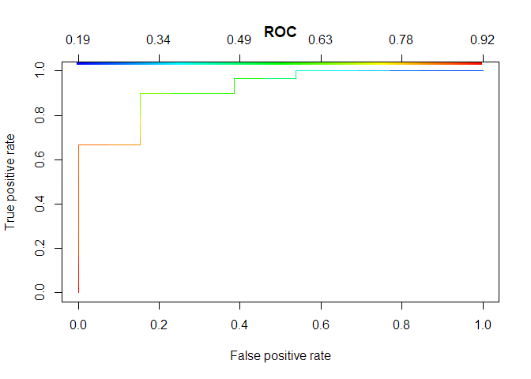

Il modello risulta molto buono ai vari cutoff potenziali che presenta. Salviamo la sequenza di questi cutoff in modo da considerare i “primi” come i cut-off rappresentanti “bassa probabilità” di risposta.

```r
train_cutoff <- sort(unique(model_auc$SL.predict))
```

## Test

Occupiamoci quindi ora di applicare il modello SuperLearner ai dati PROLOGUE.

```r
test_data <- prologue_miced_selected %>%
    dplyr::select(
        -delta_hba1c_dbl, -delta_hba1c_fct, -id, -allocation
    ) %>%
    as.data.frame() # required by SL

true_test <- as.integer(
        prologue_miced_selected[["delta_hba1c_fct"]] == "HbA1c <= -0.5"
) # required by SL

estimated_test <- predict(model_auc, test_data)[["pred"]][, 1]
test_cutoff <- sort(unique(estimated_test))
```

Anche se non siamo interessati, guardiamo l’AUC in predizione (che ci aspettiamo non sia buona, infatto lo scopo non è predire l’outcome!)

```r
# ?get_auc
get_auc(estimated_test, true_test)
```

```
#> AUC : 0.577920553893094
#> Risk: 0.422079446106906
```

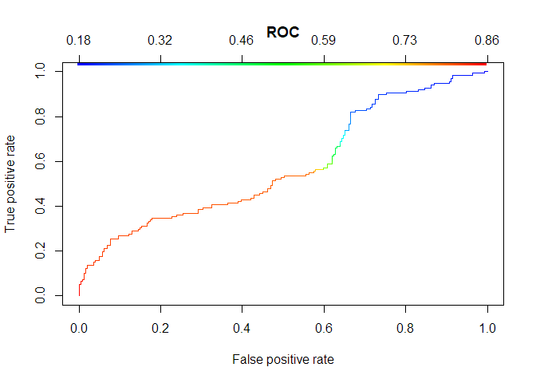

## Analisi cut-off

```r
data("prologue_miced")
# ?prologue_miced
```

Prima di tutto aggiungiamo le informazioni di allocazione per aggiustare i modelli tagliati

```r
models <- prologue_miced %>%
    dplyr::select(
        id, dm_treatment, statin, al_sbp, al_hb_a1c_jds, al_max_imt
    ) %>%
    dplyr::distinct() %>%
    dplyr::right_join(dplyr::select(prologue_miced_selected,
        id, gender, age, delta_hba1c_dbl, allocation
    )) %>%
    dplyr::mutate(
        allocation = relevel(allocation, ref = "conventional")
    )
```

Quindi creiamo una versione del database per ogni livello di cutoff (tra quelli differenti trovati nel training set… visto che ci interessa avere un uso prospettico…forse..mmm), tagliamo ciascuno a quel livello, addestriamo un modello per ciascuno (quello senza taglio non va aggiustato), e quindi estraiamo le statistiche di interesse.

```r
train_cutted_models <- models %>%
    tidyr::crossing(cutoff = c(0, train_cutoff[1:10])) %>%
    dplyr::group_by(cutoff) %>%
    tidyr::nest(.key = "full_prologue") %>%
    dplyr::mutate(

        filtered_prologue = purrr::map2(full_prologue, cutoff, ~ {
            dplyr::filter(.x, estimated_test >= .y)
        }),

        model = purrr::map(filtered_prologue, ~{

            if (nrow(.x) == 385) {
                glm(delta_hba1c_dbl ~ allocation, data = .x)
            } else {
                glm(
                    delta_hba1c_dbl ~ dm_treatment + statin + age +
                        gender + al_sbp + al_hb_a1c_jds + al_max_imt +
                        allocation,
                    data = .x
                )
            }
        }),

        size = purrr::map_int(filtered_prologue, nrow),
        aic  = purrr::map_dbl(model, ~ broom::glance(.)[["AIC"]]),

        coef_allocation = purrr::map(model, ~{
            broom::tidy(.) %>%
                dplyr::filter(term == "allocationsitagliptin") %>%
                dplyr::select(estimate, std.error, p.value)
        }),
        treat_estimate = purrr::map_dbl(coef_allocation, "estimate"),
        treat_se       = purrr::map_dbl(coef_allocation, "std.error"),
        treat_p        = purrr::map_dbl(coef_allocation, "p.value"),
        treat_lower    = treat_estimate - 1.96 * treat_se,
        treat_upper    = treat_estimate + 1.96 * treat_se,

        # utile per le etichette dell'asse x dei grafici
        x_labelled     = round(cutoff, 3) %>% paste0("\nN = ", size)
    ) %>%
    dplyr::select(-coef_allocation)
```

## Andamento della qualità dei modelli e sample size per talgio

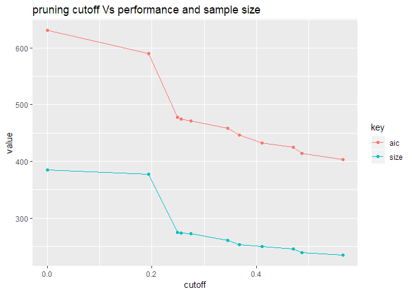

```r
train_cutted_models %>%
    tidyr::gather("key", "value", aic, size) %>%
    ggplot(aes(x = cutoff, y = value, colour = key)) +
    geom_point() +
    geom_line() +
    ggtitle("pruning cutoff Vs performance and sample size")
```

## Effetto per livello di taglio

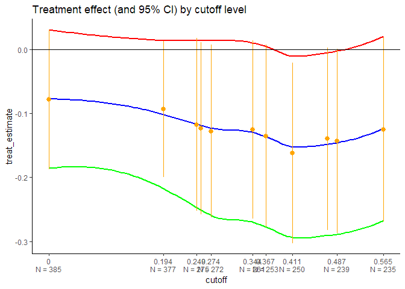

```r
train_cutted_models %>%
    ggplot(aes(x = cutoff, y = treat_estimate)) +
    geom_smooth(aes(y = treat_upper), se = FALSE, colour = "red") +
    geom_smooth(se = FALSE, colour = "blue") +
    geom_smooth(aes(y = treat_lower), se = FALSE, colour = "green") +
    geom_pointrange(aes(ymin = treat_lower, ymax = treat_upper),
        colour = "orange"
    ) +
    geom_abline(slope = 0, intercept = 0) +
    ggtitle("Treatment effect (and 95% CI) by cutoff level") +
    scale_x_continuous(
        breaks = train_cutted_models$cutoff[-c(4, 9)],
        labels = train_cutted_models$x_labelled[-c(4, 9)]
    ) +
    theme_classic()
```

### Analisi dati “migliori” Vs base

```r
base_data <- train_cutted_models$filtered_prologue[[1]]
best_data <- train_cutted_models$filtered_prologue[[7]]
```

Distribuzione confondenti per braccio (tagliato)

```r
summary(allocation ~ ., data = best_data[-1],
    method = "reverse",
    overall = TRUE,
    continuous = 4,
    test = TRUE
    ) %>%
    depigner::tidy_summary(
        prtest   = "P",
        exclude1 = FALSE,
        long     = TRUE
    ) %>%
    mutate_all(funs(str_replace_all(., "&nbsp;", " "))) %>%
    set_names(c(" ", names(.)[-1])) %>%
    pander::pander()
```

|  | conventional (N=122) | sitagliptin (N=131) | Combined (N=253) | P-value |
| --- | --- | --- | --- | --- |
| dm_treatment |  |  |  | 0.995 |
| non-pharmacological | 33% ( 40) | 33% ( 43) | 33% ( 83) |  |
| pharmacological | 67% ( 82) | 67% ( 88) | 67% (170) |  |
| statin |  |  |  | 0.742 |
| FALSE | 26% ( 32) | 24% ( 32) | 25% ( 64) |  |
| TRUE | 74% ( 90) | 76% ( 99) | 75% (189) |  |
| al_sbp | 119.00/127.50/137.75 | 117.00/128.00/138.00 | 118.00/128.00/138.00 | 0.777 |
| al_hb_a1c_jds | 6.2/6.5/6.9 | 6.2/6.5/6.9 | 6.2/6.5/6.9 | 0.8 |
| al_max_imt | 0.9200/1.3000/1.9925 | 0.9000/1.2000/1.6000 | 0.9000/1.2000/1.8000 | 0.153 |
| gender |  |  |  | 0.172 |
| male | 72% ( 88) | 64% ( 84) | 68% (172) |  |
| female | 28% ( 34) | 36% ( 47) | 32% ( 81) |  |
| age | 63/69/75 | 64/70/75 | 64/69/75 | 0.631 |
| delta_hba1c_dbl | -0.5/-0.2/ 0.0 | -0.7/-0.4/-0.2 | -0.6/-0.3/-0.1 | 0.013 |

Distribuzione confondenti per braccio (originale)

```r
summary(allocation ~ ., data = base_data[-1],
    method = "reverse",
    overall = TRUE,
    continuous = 4,
    test = TRUE
    ) %>%
    depigner::tidy_summary(
        prtest   = "P",
        exclude1 = FALSE,
        long     = TRUE
    ) %>%
    mutate_all(funs(str_replace_all(., "&nbsp;", " "))) %>%
    set_names(c(" ", names(.)[-1])) %>%
    pander::pander()
```

|  | conventional (N=193) | sitagliptin (N=192) | Combined (N=385) | P-value |
| --- | --- | --- | --- | --- |
| dm_treatment |  |  |  | 0.624 |
| non-pharmacological | 38% ( 73) | 35% ( 68) | 37% (141) |  |
| pharmacological | 62% (120) | 65% (124) | 63% (244) |  |
| statin |  |  |  | 0.508 |
| FALSE | 28% ( 54) | 25% ( 48) | 26% (102) |  |
| TRUE | 72% (139) | 75% (144) | 74% (283) |  |
| al_sbp | 119/128/138 | 118/128/138 | 118/128/138 | 0.783 |
| al_hb_a1c_jds | 6.20/6.40/6.80 | 6.20/6.45/6.80 | 6.20/6.40/6.80 | 0.695 |
| al_max_imt | 0.94/1.30/1.97 | 0.90/1.20/1.67 | 0.93/1.20/1.88 | 0.062 |
| gender |  |  |  | 0.425 |
| male | 69% (134) | 66% (126) | 68% (260) |  |
| female | 31% ( 59) | 34% ( 66) | 32% (125) |  |
| age | 64.00/70.00/76.00 | 64.00/70.00/75.25 | 64.00/70.00/76.00 | 0.87 |
| delta_hba1c_dbl | -0.50/-0.30/ 0.00 | -0.70/-0.35/-0.20 | -0.60/-0.30/-0.10 | 0.037 |

## Analisi di potenza

```r
d_adj <- sd(prologue_miced_selected$hba1c)

pwr_base <- pwr::pwr.t.test(n = 197, d = -0.1/d_adj)
ss_cutted <- pwr::pwr.t.test(d = -0.15/d_adj, power = pwr_base$power)
```

Se volessi la stessa potenza dello studio originale per individuare un effetto più grande (pari a quello dello studio tagliato) quanto sarebbe stata la sample size? (spoiler: molto meno della gente rimasta nel braccio tagliato… ma quesa cosa che senso ha? è negativa? Ha senso? … forse no. Da pensarci con calma, freschi e riposati)

```r
pwr_base
```

```
#>
#>      Two-sample t test power calculation
#>
#>               n = 197
#>               d = 0.1771638
#>       sig.level = 0.05
#>           power = 0.4185085
#>     alternative = two.sided
#>
#> NOTE: n is number in *each* group
```

```r
ss_cutted
```

```
#>
#>      Two-sample t test power calculation
#>
#>               n = 88.09588
#>               d = 0.2657457
#>       sig.level = 0.05
#>           power = 0.4185085
#>     alternative = two.sided
#>
#> NOTE: n is number in *each* group
```

Ma come va il talgio rispetto ai bracci?

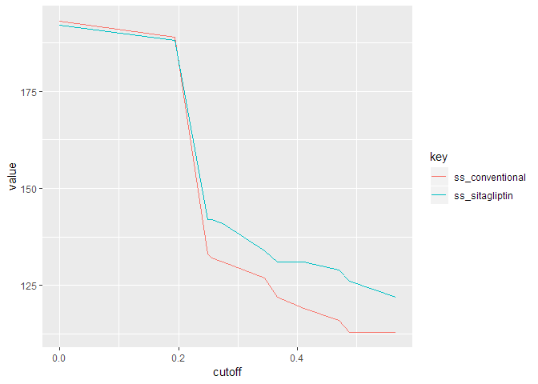

```r
train_cutted_models %>%
    mutate(
        ss_conventional = purrr::map_int(filtered_prologue, ~{
            dplyr::filter(., allocation == "conventional") %>%
                nrow()
        }),
        ss_sitagliptin = purrr::map_int(filtered_prologue, ~{
            dplyr::filter(., allocation == "sitagliptin") %>%
                nrow()
        })
    ) %>%
    dplyr::select(cutoff, ss_conventional, ss_sitagliptin) %>%
    tidyr::gather("key", "value", ss_conventional, ss_sitagliptin) %>%
    ggplot(aes(x = cutoff, y = value, colour = key)) +
    geom_line()
```

## Facciamo lo stesso talgiando per i cutoff determinati dal test set

(che non ha molto senso…forse… anche se, se lo vediamo retrospettico, forse si… pensiamoci.)

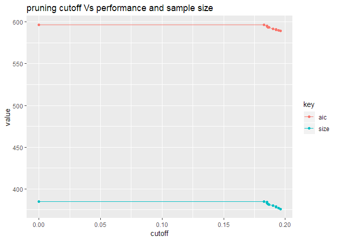

```r
test_cutted_models <- models %>%
    tidyr::crossing(cutoff = c(0, test_cutoff[1:10])) %>%
    dplyr::group_by(cutoff) %>%
    tidyr::nest(.key =  "full_prologue") %>%
    dplyr::mutate(

        filtered_prologue = purrr::map2(full_prologue, cutoff, ~ {
            dplyr::filter(.x, estimated_test >= .y)
        }),

        model = purrr::map(filtered_prologue, ~{glm(
            delta_hba1c_dbl ~ dm_treatment + statin + age + gender +
                al_sbp + al_hb_a1c_jds + al_max_imt + allocation,
            data = .
        )}),

        size = purrr::map_int(filtered_prologue, nrow),
        aic  = purrr::map_dbl(model, ~{
            broom::glance(.)[["AIC"]]
        }),
        coef_allocation = purrr::map(model, ~{
            broom::tidy(.) %>%
                dplyr::filter(term == "allocationsitagliptin") %>%
                dplyr::select(estimate, std.error, p.value)
        }),
        treat_estimate = purrr::map_dbl(coef_allocation, "estimate"),
        treat_se       = purrr::map_dbl(coef_allocation, "std.error"),
        treat_p        = purrr::map_dbl(coef_allocation, "p.value"),
        treat_lower    = treat_estimate - 1.96 * treat_se,
        treat_upper    = treat_estimate + 1.96 * treat_se,
        x_labelled     = round(cutoff, 3) %>% paste0("\nN = ", size)
    ) %>%
    dplyr::select(-coef_allocation)


test_cutted_models %>%
    tidyr::gather("key", "value", aic, size) %>%
    ggplot(aes(x = cutoff, y = value, colour = key)) +
    geom_point() +
    geom_line() +
    ggtitle("pruning cutoff Vs performance and sample size")
```

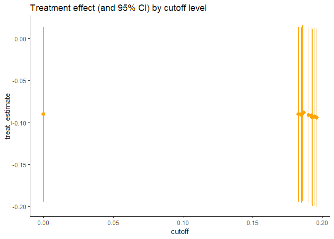

```r
test_cutted_models %>%
    ggplot(aes(x = cutoff, y = treat_estimate)) +
    geom_pointrange(aes(ymin = treat_lower, ymax = treat_upper),
        colour = "orange"
    ) +
    ggtitle("Treatment effect (and 95% CI) by cutoff level") +
    theme_classic()
```

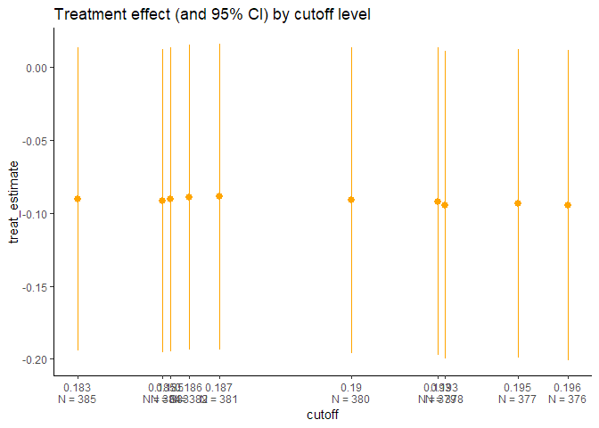

```r
test_cutted_models[-1, ] %>%
    ggplot(aes(x = cutoff, y = treat_estimate)) +
    geom_pointrange(aes(ymin = treat_lower, ymax = treat_upper),
        colour = "orange"
    ) +
    scale_x_continuous(
        breaks = test_cutted_models$cutoff,
        labels = test_cutted_models$x_labelled
    ) +
    ggtitle("Treatment effect (and 95% CI) by cutoff level") +
    theme_classic()
```